# Quantitative cross-linking data processing

```r
library(tidyverse)
library(readxl)
library(ggplot2)
library(plotly)
library(ggpubr)
library(ggforce)
library(extrafont)
library(rawR)
library(ggrepel)
```

```r
print(paste0("Report generated on:  ", Sys.Date()))
```

```
## [1] "Report generated on:  2021-09-20"
```

```r
RawXLinkProphetOutput <- read.delim("Data/XLinkProphet/iprophet-xl.xls", stringsAsFactors = FALSE)

#generated by running convert convertXLinkProphetXLStoUpload6col.pl iprophet-xl.xls 0.3065 FASTA=C:\TPP\database\yeastproteome.fasta
Raw6colOutput <- read.delim("Data/XLinkProphet/iprophet-xl_6col.txt", header=FALSE, stringsAsFactors = FALSE)
colnames(Raw6colOutput) <- c("Pep1", "Accession1", "PepPos1", "Pep2", "Accession2", "PepPos2", "ProtPos1", "ProtPos2")

SampleName = "04112020_Hpm1KO_Spheroplast"

#probability from XLinkProphet for CSMs to get a 1% FDR. This is different in every sample.
probability_01 = 0.0883
probability_comp_01 = 0.3065

#MethylQuant confidence level
MethylQuantConfidence = "High"
```

Filtering the peptide prophet results of interest by the probablity as assigned by XLinkProphet

```r
FilteredCSMs <- RawXLinkProphetOutput %>%
  filter(probability >= probability_01)

FilteredRedundantCrosslinks <- RawXLinkProphetOutput %>%
  filter(composite_probability >= probability_comp_01) %>%
  distinct()
```

Processing to combined IDs and generate different levels of redundancy

```r
ReturnXL_Stripped <- function(PeptideWithMods) {
  StrippedPep <- str_remove_all(PeptideWithMods, "\\[(.*?)\\]")
       return(StrippedPep)
}

AlphabetizeXLKey <- function(XLPep1, XLPep2) {
  Interaction <- if_else(XLPep1 == XLPep2, paste0(XLPep1, "_", XLPep2), if_else(XLPep1 < XLPep2, paste0(XLPep1, "_", XLPep2), paste0(XLPep2, "_", XLPep1)))
    return(Interaction)
}

AddKey <- function( input_table, Level) {
  nrows <- nrow(input_table)
    if(Level == "XL")
  {
    for (i in 1:nrows) {
      input_table$Pep1[i] <- ReturnXL_Stripped(input_table$Pep1[i])
      input_table$Pep2[i] <- ReturnXL_Stripped(input_table$Pep2[i])
      input_table$XLPep1[i] <- paste0(input_table$Pep1[i], "-", input_table$PepPos1[i], "-", input_table$Accession1[i])
      input_table$XLPep2[i] <- paste0(input_table$Pep2[i], "-", input_table$PepPos2[i], "-", input_table$Accession2[i])
      input_table$XL_Key[i] <- AlphabetizeXLKey(input_table$XLPep1[i], input_table$XLPep2[i])
    }
    return(input_table)
  }

  else if (Level == "URP") {
    for (i in 1:nrows) {
      input_table$Pep1[i] <- ReturnXL_Stripped(input_table$Pep1[i])
      input_table$Pep2[i] <- ReturnXL_Stripped(input_table$Pep2[i])
      input_table$ResidueKey1[i] <- paste0(input_table$Accession1[i], "-", input_table$ProtPos1[i])
      input_table$ResidueKey2[i] <- paste0(input_table$Accession2[i], "-", input_table$ProtPos2[i])
      input_table$URP_Key[i] <- AlphabetizeXLKey(input_table$ResidueKey1[i], input_table$ResidueKey2[i])
    }
    return(input_table)
  }

  else if (Level == "PPI") {
    for (i in 1:nrows) {
      input_table$PPI_Key[i] <- AlphabetizeXLKey(input_table$Accession1[i], input_table$Accession2[i])
    }
    return(input_table)
  }
}

#Useful functions to return the 0-based position of the crosslink mod (325.13 = light PIR stump mass, 333.14 = heavy labelled stump mass)
#or strip the peptide sequence, as exported by XLinkProphet under the heading peptide1/peptide2, of any mods. Useful for XLinkDB upload.
ReturnXL_PepPos <- function(PeptideWithMods) {
    V1 <- str_replace(PeptideWithMods, "\\[325\\.13\\]", "x")
    V1 <- str_replace(V1, "\\[333\\.14\\]", "x")
    V1 <- str_remove_all(V1, "\\[(.*?)\\]")
    V1 <- str_locate(V1, "x")[1]

    #make 0-based modPos
    V1 <- V1 -2
    return(V1);
}

CleanXLinkProphet <- function(XlinkProphet_output) {
  nrows <- nrow(XlinkProphet_output)

  for (i in 1:nrows) {
  XlinkProphet_output$Accession1[i] <- str_remove(str_sub(XlinkProphet_output$protein1[i], 1, 9), "sp\\|" )
  XlinkProphet_output$Accession2[i] <-  str_remove(str_sub(XlinkProphet_output$protein2[i], 1, 9), "sp\\|" )
  XlinkProphet_output$PepPos1[i] <- ReturnXL_PepPos(XlinkProphet_output$peptide1[i])
  XlinkProphet_output$PepPos2[i] <- ReturnXL_PepPos(XlinkProphet_output$peptide2[i])
  XlinkProphet_output$Pep1[i] <- ReturnXL_Stripped(XlinkProphet_output$peptide1[i])
  XlinkProphet_output$Pep2[i] <- ReturnXL_Stripped(XlinkProphet_output$peptide2[i])
    }

  return(XlinkProphet_output);
}

CleanXlinkProphetTable <- AddKey(CleanXLinkProphet(FilteredCSMs), "XL")
FilteredRedundantCrosslinks <- AddKey(CleanXLinkProphet(FilteredRedundantCrosslinks), "XL")



Clean6colTable <- AddKey(Raw6colOutput, "PPI")
Clean6colTable <- AddKey(Clean6colTable, "URP")
Clean6colTable <- AddKey(Clean6colTable, "XL")
Clean6colTable <- Clean6colTable %>%  select(XL_Key, URP_Key, PPI_Key, ResidueKey1, ResidueKey2)

AnnotatedXLTable <- distinct(full_join(CleanXlinkProphetTable, Clean6colTable, by = "XL_Key" ))
write.table(AnnotatedXLTable, file = paste0(SampleName, "_AnnotatedXLTable.txt"), sep = "\t", row.names = FALSE, quote = FALSE)
```

```r
APID <- read.delim("Data/APID/559292_noISI_Q3_June2021.txt", stringsAsFactors=FALSE)

APID <- APID %>%
  filter(ExpEvidences >= 1) %>%
  rename(Accession1 = UniprotID_A, Accession2 = UniprotID_B) %>%
  mutate(KnownAPID = TRUE)

APID <- AddKey(APID, "PPI")


PPIs <- AnnotatedXLTable %>%
  filter(intra != 1) %>%
  filter(!is.na(PPI_Key)) %>%
  group_by(PPI_Key) %>%
  summarise(NumURPs = n_distinct(URP_Key), NumCSMs = n()) %>%
  distinct()

PPI_URPs <- AnnotatedXLTable %>%
  filter(intra != 1) %>%
    filter(!is.na(PPI_Key)) %>%
  select(PPI_Key, URP_Key) %>%
  distinct()

PPIs <- left_join(PPIs, APID, by = "PPI_Key")

PPIs <- PPIs %>%
  mutate(KnownAPID = replace_na(KnownAPID, FALSE)) %>%
  separate(PPI_Key, into = c("AccessionA", "AccessionB"), sep = "_",remove= FALSE )

PPI_URPs <- left_join(PPI_URPs, PPIs, by = "PPI_Key")

write.table(PPIs, file = "IdentifiedPPIs.txt", sep = "\t", quote = FALSE, row.names = FALSE)
write.table(PPI_URPs, file = "IdentifiedPPI_URPs.txt", sep = "\t", quote = FALSE, row.names = FALSE)
```

Generating a table for structural analysis in another script.

```r
URPs <- AnnotatedXLTable %>%
  filter(composite_probability >= probability_comp_01) %>%
  select(URP_Key) %>%
  separate(URP_Key, sep = "_", into = c("Residue1", "Residue2"), remove = FALSE) %>%
  separate(Residue1, sep = "-", into = c("Accession1", "Lys1"), remove = FALSE) %>%
  separate(Residue2, sep = "-", into = c("Accession2", "Lys2"), remove = FALSE) %>%
  distinct()

write.table(URPs, file = "URPsForMapping.txt", row.names = FALSE, quote = FALSE, sep = "\t")
```

Make an input table for XLinkDB

```r
XLinkDBTable <- AnnotatedXLTable %>%
  select(Pep1, Accession1, PepPos1, Pep2, Accession2, PepPos2) %>%
  distinct()

write.table(XLinkDBTable, file = paste0("XLinkDBInput_", SampleName, ".txt"), sep = "\t", col.names = FALSE, row.names = FALSE, quote = FALSE)
```

Generating a table of CSMs compatible for analysis with MethylQuant Converting the calculated crosslink monoisotopic parent mass (theoretically determined by Comet when using C13 isotope error in search) to a m/z and calculate the theoretical isotope labelling pair. This is useful for use with MethylQuant, where you provide a list of m/z, charges, scans and mass differences (actually, a m/z difference calculated by taking into account the number of arginines and lysines present in the sequence, and the parent charge). Searching for m/z’s of real spectral identifications, and also for masses in other replicates (matches between runs idea).

```r
TableForMethylQuant <- AnnotatedXLTable %>%
  mutate(isLIGHT_ID = str_detect(peptide1, "325.13")) %>%
  mutate(Sequence = str_replace_all(composite_id, "_", "")) %>%
  mutate(Sequence = str_replace_all(Sequence, "x", "")) %>%
  mutate(NumLysines = str_count(Sequence, "K")) %>%
  mutate(NumArginines = str_count(Sequence, "R")) %>%
  mutate(mono_parent_mass = peptide1_mass + peptide2_mass + 693.399601) %>%
  mutate(HeavyMZshift = ((NumLysines * 8.014199) + (NumArginines * 10.008269))/parent_charge) %>%
  mutate(MZ = (mono_parent_mass + (parent_charge * 1.00728))/parent_charge) %>%
  mutate(MZShift = ifelse(isLIGHT_ID == FALSE, HeavyMZshift * -1, HeavyMZshift)) %>%
  mutate(Modifications = "") %>%
  rename(Charge = `parent_charge`) %>%
  rename("Calc m/z" = MZ) %>%
  rename("Mass Difference" = MZShift) %>%
  mutate(realID = TRUE)

nrows <- nrow(TableForMethylQuant)
for (i in 1:nrows) {
  TableForMethylQuant$SpecID[i] <- tail(strsplit(TableForMethylQuant$spectrum[i],"\\\\")[[1]],1)
  TableForMethylQuant$'Data File'[i] <- paste0(str_split_fixed(TableForMethylQuant$SpecID[i], "\\.", n =4)[,1], ".raw")
  TableForMethylQuant$'Start Scan'[i] <- str_split_fixed(TableForMethylQuant$SpecID[i], "\\.", n =4)[,2]
}

TableForMethylQuant <- TableForMethylQuant %>%
  filter(!is.na(`Data File`))

DuplicateRV_1 <- TableForMethylQuant %>%
  filter(!(str_detect(`Data File`, "RV_") & str_detect(`Data File`, "_1.raw"))) %>%
  mutate(`Data File` = str_replace(`Data File`, "FWD", "RV")) %>%
  mutate(`Data File` = str_replace(`Data File`, "_2.raw", "_1.raw")) %>%
  select(Accession1:`Start Scan`, peptide1_mass, peptide2_mass, parent_mass, Charge) %>%
  select(-SpecID) %>%
  mutate(realID = FALSE)

DuplicateRV_2 <- TableForMethylQuant %>%
  filter(!(str_detect(`Data File`, "RV_") & str_detect(`Data File`, "_2.raw"))) %>%
  mutate(`Data File` = str_replace(`Data File`, "FWD", "RV")) %>%
  mutate(`Data File` = str_replace(`Data File`, "_1.raw", "_2.raw")) %>%
  select(Accession1:`Start Scan`, peptide1_mass, peptide2_mass, parent_mass, Charge) %>%
  select(-SpecID) %>%
  mutate(realID = FALSE)


DuplicateFWD_1 <- TableForMethylQuant %>%
  filter(!(str_detect(`Data File`, "FWD_") & str_detect(`Data File`, "_1.raw"))) %>%
  mutate(`Data File` = str_replace(`Data File`, "RV", "FWD")) %>%
  mutate(`Data File` = str_replace(`Data File`, "_2.raw", "_1.raw")) %>%
  select(Accession1:`Start Scan`, peptide1_mass, peptide2_mass, parent_mass, Charge) %>%
  select(-SpecID) %>%
  mutate(realID = FALSE)


DuplicateFWD_2 <- TableForMethylQuant %>%
  filter(!(str_detect(`Data File`, "FWD_") & str_detect(`Data File`, "_2."))) %>%
  mutate(`Data File` = str_replace(`Data File`, "RV", "FWD")) %>%
  mutate(`Data File` = str_replace(`Data File`, "_1.raw", "_2.raw")) %>%
  select(Accession1:`Start Scan`, peptide1_mass, peptide2_mass, parent_mass, Charge) %>%
  select(-SpecID) %>%
  mutate(realID = FALSE)

TableForMethylQuant <- bind_rows(TableForMethylQuant, DuplicateRV_1, DuplicateRV_2, DuplicateFWD_1, DuplicateFWD_2)

TableForMethylQuant <- TableForMethylQuant %>%
    select(Accession1:`Start Scan`, peptide1_mass, peptide2_mass, parent_mass, Charge) %>%
  distinct() %>%
  filter(!is.na(`Data File`)) %>%
  filter(!is.na(Sequence))

TableForMethylQuant <- distinct(TableForMethylQuant)

write.csv(TableForMethylQuant, file = paste0("TableForMethylQuant_IDsDuplicated", SampleName, ".csv"), row.names = FALSE, quote = TRUE)
```

Protein level normalisation factor extrapolation. Taking the normalisation factor for crosslink ratios by extrapolating normalisation factor from MaxQuant results of the matched proteome analysis.

```r
proteinGroupsFWD <- read.delim("Data/MaxQuant/FW/proteinGroups.txt", stringsAsFactors=FALSE)
proteinGroupsRV <- read.delim("Data/MaxQuant/RV/proteinGroups.txt", stringsAsFactors=FALSE)

proteinGroupsFWD <- proteinGroupsFWD %>%
  mutate(Replicate = "FWD")

proteinGroupsRV <- proteinGroupsRV %>%
  mutate(Replicate = "RV")

ProteinswithRatiosFWD <- proteinGroupsFWD %>%
  filter(Ratio.H.L<100)

FWD.meanProteinH.L = mean(ProteinswithRatiosFWD$Ratio.H.L)
FWD.meanProteinH.L
```

```
## [1] 0.6823332
```

```r
ProteinswithRatiosRV <- proteinGroupsRV %>%
  filter(Ratio.H.L<100)

RV.meanProteinH.L = mean(ProteinswithRatiosRV$Ratio.H.L)
RV.meanProteinH.L
```

```
## [1] 0.6504095
```

MethylQuant output cleaning, to check the quantified species match input by comparing PPM, and also filtering quanification above a score of 10.

```r
MethylQuantOutput <- read_csv("Data/MethylQuant/TableForMethylQuant_IDsDuplicated04112020_Hpm1KO_Spheroplast_MethylQuant.csv")
MethylQuantOutputLight <- MethylQuantOutput %>%
  filter(isLIGHT_ID == TRUE) %>%
  mutate(LightMZ =`Calc m/z`) %>%
  mutate(MethylQuantMassDiffLight = ((`Light m/z 1 IsotopeCorrelation`- LightMZ))) %>%
  mutate(MethylQuantMassDiffLightPPM = abs(((`Light m/z 1 IsotopeCorrelation`- LightMZ)/LightMZ)*1000000) ) %>%
  mutate(HeavyMZ = `Calc m/z` + `Mass Difference`) %>%
  mutate(MethylQuantMassDiffHeavy = ((`Heavy m/z 1 IsotopeCorrelation`- HeavyMZ))) %>%
  mutate(MethylQuantMassDiffHeavyPPM = abs(((`Heavy m/z 1 IsotopeCorrelation`-  HeavyMZ)/HeavyMZ)*1000000) )

MethylQuantOutputHeavy <- MethylQuantOutput %>%
  filter(isLIGHT_ID == FALSE) %>%
  mutate(LightMZ = `Calc m/z` + `Mass Difference`) %>%
  mutate(MethylQuantMassDiffLight = ((`Light m/z 1 IsotopeCorrelation`- LightMZ))) %>%
  mutate(MethylQuantMassDiffLightPPM = abs(((`Light m/z 1 IsotopeCorrelation`- LightMZ)/LightMZ)*1000000) ) %>%
  mutate(HeavyMZ =  `Calc m/z`) %>%
  mutate(MethylQuantMassDiffHeavy = ((`Heavy m/z 1 IsotopeCorrelation`- HeavyMZ))) %>%
  mutate(MethylQuantMassDiffHeavyPPM = abs(((`Heavy m/z 1 IsotopeCorrelation`-  HeavyMZ)/HeavyMZ)*1000000) )

MethylQuantOutput <- bind_rows(MethylQuantOutputLight, MethylQuantOutputHeavy)

MethylQuantOutput <- MethylQuantOutput %>%
  mutate(Iso2Light = LightMZ + (1.00866491588/Charge)) %>%
  mutate(Iso3Light = Iso2Light + (1.00866491588/Charge)) %>%
  mutate(Iso2LightPPM = ((Iso2Light -  `Light m/z 2 IsotopeCorrelation`)/Iso2Light)*100000) %>%
  mutate(Iso3LightPPM = ((Iso3Light -  `Light m/z 3 IsotopeCorrelation`)/Iso3Light)*100000) %>%
  mutate(Iso2Heavy = HeavyMZ + (1.00866491588/Charge)) %>%
  mutate(Iso3Heavy = Iso2Heavy + (1.00866491588/Charge)) %>%
  mutate(Iso2HeavyPPM = ((Iso2Heavy -  `Heavy m/z 2 IsotopeCorrelation`)/Iso2Heavy)*100000) %>%
  mutate(Iso3HeavyPPM = ((Iso3Heavy-  `Heavy m/z 3 IsotopeCorrelation`)/Iso3Heavy)*100000)


MethylQuantOutput <- MethylQuantOutput %>%
  mutate(Replicate = if_else(str_detect(`Data File`, "RV_"), "RV", "FWD")) %>%
  mutate(XL_ID = row_number())

PepsWithRatios <- MethylQuantOutput %>%
  filter(!is.na(`H/L Ratio #2`)) %>%
  filter(MethylQuantMassDiffHeavyPPM <= 10) %>%
  filter(MethylQuantMassDiffLightPPM <= 10) %>%
  filter(`MethylQuant Score` > 10)
```

Remove crosslinked peptides containing methionine oxidation, which may interfere with quantification

```r
MethioninePeps <- AnnotatedXLTable %>%
  filter(str_detect(composite_id, "147.04"))

  for (i in 1:NROW(MethioninePeps)) {
     MethioninePeps$spectrum[i] = tail(strsplit(MethioninePeps$spectrum[i],"\\\\")[[1]],1)
}

PepsWithRatios <- anti_join(PepsWithRatios, MethioninePeps, by = c("SpecID" = "spectrum"))
```

```r
FilteredRedundantCrosslinks <- FilteredRedundantCrosslinks %>%
  select(XL_Key) %>%
  mutate(ValidCrosslink = TRUE) %>%
  distinct()

PepsWithRatios <- inner_join(PepsWithRatios, FilteredRedundantCrosslinks, by = "XL_Key" )

PepsWithRatios <- distinct(PepsWithRatios)
```

Normalising SILAC ratios using protein level normalisation factor, which was was the mean protein H/L ratio from matched proteomics experiments. Summarising to URPs and only taking URP that were quantified in both replicates.

```r
URPsQuantifiedInBoth <- PepsWithRatios %>%
  select(XL_Key, URP_Key, PPI_Key,  `Data File`, Replicate, `H/L Ratio #2`, `MethylQuant Score`) %>%
  group_by(XL_Key, URP_Key, PPI_Key,  `Data File`, Replicate) %>%
  top_n(n = 1, wt = `MethylQuant Score`) %>%
  distinct() %>%
  ungroup() %>%
  mutate(NormCrosslinkRatio = if_else(Replicate == "RV", `H/L Ratio #2`/RV.meanProteinH.L, `H/L Ratio #2`/FWD.meanProteinH.L)) %>%
  mutate(NormCrosslinkLog2Ratio = log2(NormCrosslinkRatio)) %>%
  mutate(NormCrosslinkLog2_KO_WT_Ratio = if_else(Replicate == "RV", NormCrosslinkLog2Ratio * -1, NormCrosslinkLog2Ratio )) %>%
  select(XL_Key, URP_Key, PPI_Key, NormCrosslinkLog2_KO_WT_Ratio,  `Data File`,  Replicate) %>%
  group_by(URP_Key, PPI_Key) %>%
  summarise(AvgCorrectXLRatio = mean(NormCrosslinkLog2_KO_WT_Ratio),
            MedianCorrectXLRatio = median(NormCrosslinkLog2_KO_WT_Ratio),
            NumRatios = n(),
            sd = sd(NormCrosslinkLog2_KO_WT_Ratio),
            Ratios = list(NormCrosslinkLog2_KO_WT_Ratio),
            NumBioReplicates = n_distinct(Replicate)) %>%
  ungroup() %>%
  separate(URP_Key, c("ResidueKey1", "ResidueKey2"), sep = "_", remove = FALSE)  %>%
  separate(ResidueKey1, c("Accession1", "Residue1"), sep = "-", remove = FALSE) %>%
  separate(ResidueKey2, c("Accession2", "Residue2"), sep = "-", remove = FALSE) %>%
  filter(NumRatios > 1) %>%
  filter(NumBioReplicates == 2)
```

Performing two-tailed, unpaired t-tests to compare crosslink ratios to a ratio value of 0 (no change). Using the Benjamini-Hochberg (“fdr”) method correct for multiple testing, generating adjusted p-values.

```r
URPsQuantifiedInBoth$Pval = NA

for (i in 1:NROW(URPsQuantifiedInBoth)){

  Ratios = unlist(URPsQuantifiedInBoth$Ratios[i])
  TTestResult = t.test(Ratios, mu = 0, alternative = "two.sided")
  URPsQuantifiedInBoth$Pval[i] = TTestResult$p.value[1]

}

AdjustedPValues <- data.frame()
AdjustedPValues <- p.adjust(URPsQuantifiedInBoth$Pval, method = "fdr")

URPsQuantifiedInBoth$Adj.Pval <- AdjustedPValues
```

Annotating information about proteins from UNIPROT

```r
UNIPROT <- read.delim("Data/UniProt/UNIPROT_Yeast.txt", stringsAsFactors=FALSE)
UNIPROT <- UNIPROT %>%
  mutate(Gene.names.primary.1 = paste0(str_to_sentence(Gene.names...primary.., locale = "en"), "p")) %>%
  rename(Entry.name.1 = Entry.name) %>%
  select(Entry, Entry.name.1, Gene.names.primary.1)


URPsQuantifiedInBoth <- left_join(URPsQuantifiedInBoth, UNIPROT, by = c("Accession1" = "Entry"))

UNIPROT <- UNIPROT %>%
  rename(Entry.name.2 = Entry.name.1,
         Gene.names.primary.2 = Gene.names.primary.1)
URPsQuantifiedInBoth <- left_join(URPsQuantifiedInBoth, UNIPROT, by = c("Accession2" = "Entry"))
```

Generating volcano plot. Purposely excluding one extreme value for visibilities sake

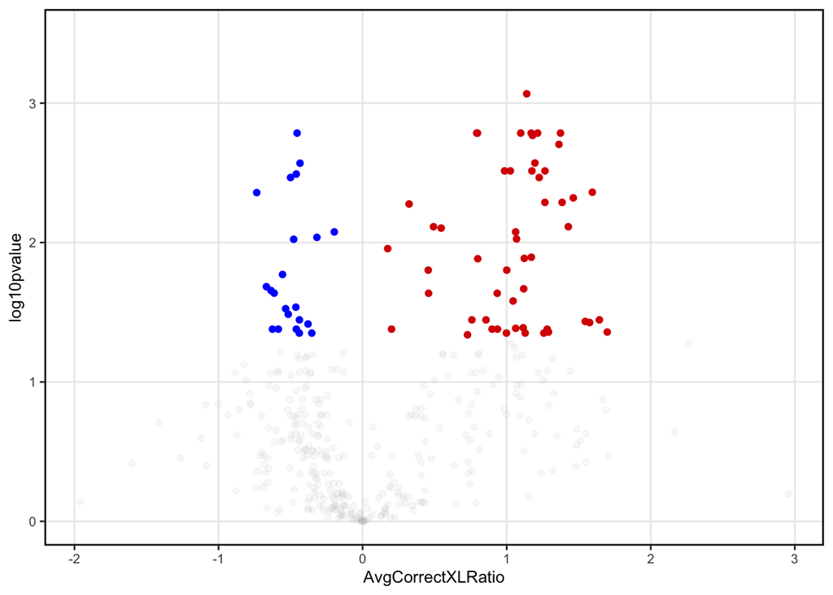

```r
ForVolcano <- URPsQuantifiedInBoth %>%
    mutate(log10pvalue = -1* log10(Adj.Pval)) %>%
    mutate(Direction = case_when(
    (Adj.Pval <= 0.05) & (AvgCorrectXLRatio > 0) ~ "Up",
    (Adj.Pval <= 0.05) & (AvgCorrectXLRatio < 0) ~ "Down",
    (Adj.Pval > 0.05)  ~"Not")) %>%
    mutate(LabelName = paste0(Gene.names.primary.1, "-\n", Gene.names.primary.2)) %>%
    #mutate(LabelName =  Gene.names.primary.1) %>%
  mutate(Label = if_else(((Adj.Pval < 0.05) & (abs(AvgCorrectXLRatio >= 0.7))), TRUE, FALSE)) %>%
    mutate(Alpha = if_else(Adj.Pval <= 0.05, TRUE, FALSE))



ggplot(ForVolcano, aes(x = AvgCorrectXLRatio, y = log10pvalue,  color = Direction ,alpha = Alpha, label = LabelName)) +
  geom_jitter() +
  #geom_text_repel(data = subset(ForVolcano, Label == TRUE), size = 3) +
  scale_color_manual(values = c( "#0000FF", "#bababa", "#D90000")) +
  theme_bw() +
  theme(legend.position = "none",
        text=element_text(size=10,  family="Arial"),
        panel.border = element_rect(fill=NA, colour = "black", size=1),
        panel.grid.minor = element_blank()) +
  #xlim(-2.3,2.3)+
 ylim(0, 3.5)
```

```r
ggsave(filename = "CrosslinkVolcano.pdf", device = cairo_pdf,
       width = 3, height = 3, units = "in")
```

Grouping URPs by signifcance level

```r
SignificantlyChanging_URPs <- URPsQuantifiedInBoth %>%
  filter(Adj.Pval <= 0.05)

SignificantlyChanging_URPs
```

| URP_Key | ResidueKey1 | Accession1 | Residue1 | ResidueKey2 | Accession2 | Residue2 | PPI_Key | AvgCorrectXLRatio | MedianCorrectXLRatio | NumRatios | sd | Ratios | NumBioReplicates | Pval | Adj.Pval | Entry.name.1 | Gene.names.primary.1 | Entry.name.2 | Gene.names.primary.2 |
| --- | --- | --- | --- | --- | --- | --- | --- | --- | --- | --- | --- | --- | --- | --- | --- | --- | --- | --- | --- |
| P00358-191_P00358-212 | P00358-191 | P00358 | 191 | P00358-212 | P00358 | 212 | P00358_P00358 | -0.1963584 | -0.2154171 | 5 | 0.045899233 |  | 2 | 6.671747e-04 | 8.393489e-03 | G3P2 | Tdh2p | G3P2 | Tdh2p |
| P00925-337_P00925-396 | P00925-337 | P00925 | 337 | P00925-396 | P00925 | 396 | P00925_P00925 | 0.7972383 | 0.7873114 | 4 | 0.039817155 |  | 2 | 3.426517e-05 | 1.640087e-03 | ENO2 | Eno2p | ENO2 | Eno2p |
| P02293-22_P02294-16 | P02293-22 | P02293 | 22 | P02294-16 | P02294 | 16 | P02293_P02294 | 1.0621494 | 0.8434090 | 7 | 0.434193854 |  | 2 | 6.458538e-04 | 8.393489e-03 | H2B1 | Htb1p | H2B2 | Htb2p |
| P02294-111_P02294-123 | P02294-111 | P02294 | 111 | P02294-123 | P02294 | 123 | P02294_P02294 | 1.1068331 | 1.0700254 | 14 | 0.172309072 |  | 2 | 3.695912e-12 | 1.441406e-09 | H2B2 | Htb2p | H2B2 | Htb2p |
| P02294-111_P04911-21 | P02294-111 | P02294 | 111 | P04911-21 | P04911 | 21 | P02294_P04911 | 1.2900358 | 1.2917031 | 4 | 0.403806884 |  | 2 | 7.763649e-03 | 4.388149e-02 | H2B2 | Htb2p | H2A1 | Hta1p |
| P02294-111_P61830-79 | P02294-111 | P02294 | 111 | P61830-79 | P61830 | 79 | P02294_P61830 | 1.0445580 | 1.0117147 | 4 | 0.241039314 |  | 2 | 3.231585e-03 | 2.625663e-02 | H2B2 | Htb2p | H3 | Hht1; hht2p |
| P02294-123_P02294-46 | P02294-123 | P02294 | 123 | P02294-46 | P02294 | 46 | P02294_P02294 | 1.4277615 | 1.4985942 | 5 | 0.315450632 |  | 2 | 5.364920e-04 | 7.701520e-03 | H2B2 | Htb2p | H2B2 | Htb2p |
| P02294-123_P02294-49 | P02294-123 | P02294 | 123 | P02294-49 | P02294 | 49 | P02294_P02294 | 1.1698850 | 1.1623248 | 6 | 0.182412430 |  | 2 | 1.900246e-05 | 1.640087e-03 | H2B2 | Htb2p | H2B2 | Htb2p |
| P02294-123_P02309-77 | P02294-123 | P02294 | 123 | P02309-77 | P02309 | 77 | P02294_P02309 | 1.2258648 | 1.0937017 | 7 | 0.392097120 |  | 2 | 1.689615e-04 | 3.417555e-03 | H2B2 | Htb2p | H4 | Hhf1; hhf2p |
| P02294-123_P04911-7 | P02294-123 | P02294 | 123 | P04911-7 | P04911 | 7 | P02294_P04911 | 1.0625387 | 1.3590246 | 5 | 0.453522868 |  | 2 | 6.345520e-03 | 4.124588e-02 | H2B2 | Htb2p | H2A1 | Hta1p |

[output cut: 65 more lines]

```r
NonChanging_URPS <- URPsQuantifiedInBoth %>%
  filter(Adj.Pval > 0.05)
NonChanging_URPS
```

| URP_Key | ResidueKey1 | Accession1 | Residue1 | ResidueKey2 | Accession2 | Residue2 | PPI_Key | AvgCorrectXLRatio | MedianCorrectXLRatio | NumRatios | sd | Ratios | NumBioReplicates | Pval | Adj.Pval | Entry.name.1 | Gene.names.primary.1 | Entry.name.2 | Gene.names.primary.2 |
| --- | --- | --- | --- | --- | --- | --- | --- | --- | --- | --- | --- | --- | --- | --- | --- | --- | --- | --- | --- |
| O14455-15_P05745-12 | O14455-15 | O14455 | 15 | P05745-12 | P05745 | 12 | O14455_P05745 | -0.152601552 | 0.033000707 | 3 | 0.64313272 |  | 2 | 0.72093917 | 0.81972675 | RL36B | Rpl36bp | RL36A | Rpl36ap |
| O74700-50_P87108-41 | O74700-50 | O74700 | 50 | P87108-41 | P87108 | 41 | O74700_P87108 | 1.253158043 | 1.141005625 | 3 | 0.37870412 |  | 2 | 0.02911850 | 0.09720252 | TIM9 | Tim9p | TIM10 | Tim10p |
| P00330-318_P00330-334 | P00330-318 | P00330 | 318 | P00330-334 | P00330 | 334 | P00330_P00330 | -0.118246909 | -0.118246909 | 2 | 0.72526983 |  | 2 | 0.85573503 | 0.91270055 | ADH1 | Adh1p | ADH1 | Adh1p |
| P00358-191_P00358-216 | P00358-191 | P00358 | 191 | P00358-216 | P00358 | 216 | P00358_P00358 | -0.372183402 | -0.320663457 | 4 | 0.31151320 |  | 2 | 0.09678329 | 0.21086862 | G3P2 | Tdh2p | G3P2 | Tdh2p |
| P00358-191_P00358-260 | P00358-191 | P00358 | 191 | P00358-260 | P00358 | 260 | P00358_P00358 | -0.699356426 | -1.051110464 | 4 | 0.81356564 |  | 2 | 0.18406233 | 0.31904138 | G3P2 | Tdh2p | G3P2 | Tdh2p |
| P00358-212_P00358-330 | P00358-212 | P00358 | 212 | P00358-330 | P00358 | 330 | P00358_P00358 | -0.173509288 | -0.258993736 | 3 | 0.33832781 |  | 2 | 0.46811300 | 0.62521941 | G3P2 | Tdh2p | G3P2 | Tdh2p |
| P00358-216_P00358-256 | P00358-216 | P00358 | 216 | P00358-256 | P00358 | 256 | P00358_P00358 | -0.222931771 | -0.053792114 | 5 | 0.42733431 |  | 2 | 0.30821215 | 0.45442575 | G3P2 | Tdh2p | G3P2 | Tdh2p |
| P00358-216_P00358-266 | P00358-216 | P00358 | 216 | P00358-266 | P00358 | 266 | P00358_P00358 | 0.004671918 | -0.600668772 | 3 | 1.43541987 |  | 2 | 0.99601381 | 0.99601381 | G3P2 | Tdh2p | G3P2 | Tdh2p |
| P00358-216_P00358-330 | P00358-216 | P00358 | 216 | P00358-330 | P00358 | 330 | P00358_P00358 | -0.008404126 | -0.275976128 | 4 | 0.63001790 |  | 2 | 0.98039123 | 0.99478541 | G3P2 | Tdh2p | G3P2 | Tdh2p |
| P00358-248_P00358-266 | P00358-248 | P00358 | 248 | P00358-266 | P00358 | 266 | P00358_P00358 | -0.003989829 | 0.105182090 | 4 | 1.06850886 |  | 2 | 0.99451028 | 0.99601381 | G3P2 | Tdh2p | G3P2 | Tdh2p |

[output cut: 305 more lines]

Annoting protein level change to changing URPs

```r
proteinGroupsCombined <- bind_rows(proteinGroupsFWD, proteinGroupsRV)

filteredProteinGroups <- proteinGroupsCombined %>%
  separate_rows(Majority.protein.IDs, sep =";") %>%
  filter(!is.na(Ratio.H.L.normalized)) %>%
  filter(Ratio.H.L.variability.... < 30) %>%
  filter(!str_detect(Protein.IDs, "CON_")) %>%
  filter(!str_detect(Protein.IDs, "REV_")) %>%
  mutate(Accession1 =  str_remove(str_sub(Majority.protein.IDs, 1, 9), "sp\\|" )) %>%
  rename(NormProteinRatio = Ratio.H.L.normalized) %>%
  mutate(NormProteinLog2Ratio = log2(NormProteinRatio)) %>%
  mutate(NormProteinLog2_KO_WT_ratio = if_else(Replicate == "RV", NormProteinLog2Ratio * -1, NormProteinLog2Ratio)) %>%
  select(NormProteinLog2_KO_WT_ratio, Accession1, Fasta.headers, Ratio.H.L, Ratio.H.L.variability...., Ratio.H.L.count, Replicate)

#average over replicates
MeanRatioProteinLevel <- filteredProteinGroups %>%
  group_by(Accession1) %>%
  summarise(Mean_NormProteinLog2_KO_WT_ratio.Protein.1 = mean(NormProteinLog2_KO_WT_ratio))

SignificantlyChanging_URPs <- left_join(SignificantlyChanging_URPs, MeanRatioProteinLevel, by = c("Accession1" = "Accession1"))

MeanRatioProteinLevel <- MeanRatioProteinLevel %>%
  rename(Mean_NormProteinLog2_KO_WT_ratio.Protein.2 = Mean_NormProteinLog2_KO_WT_ratio.Protein.1)
SignificantlyChanging_URPs <- left_join(SignificantlyChanging_URPs, MeanRatioProteinLevel, by = c("Accession2" = "Accession1"))
```

Comparing URP ratios to protein level changes, two-tailed, unpaired t-test, with “fdr” method of multiple testing comparison

```r
SignificantlyChanging_URPs_withProteinQuant <- SignificantlyChanging_URPs %>%
  filter(!is.na(Mean_NormProteinLog2_KO_WT_ratio.Protein.1)) %>%
  filter(!is.na(Mean_NormProteinLog2_KO_WT_ratio.Protein.2))


for (i in 1:NROW(SignificantlyChanging_URPs_withProteinQuant)){

  Ratios = unlist(SignificantlyChanging_URPs_withProteinQuant$Ratios[i])

  Test.1 = t.test(Ratios, mu = SignificantlyChanging_URPs_withProteinQuant$Mean_NormProteinLog2_KO_WT_ratio.Protein.1[i], alternative = "two.sided")
  SignificantlyChanging_URPs_withProteinQuant$Pval.againstProtein.1[i] = Test.1$p.value[1]

  Test.2 = t.test(Ratios, mu = SignificantlyChanging_URPs_withProteinQuant$Mean_NormProteinLog2_KO_WT_ratio.Protein.2[i], alternative = "two.sided")
  SignificantlyChanging_URPs_withProteinQuant$Pval.againstProtein.2[i] = Test.2$p.value[1]
}
Adjusted1 <- data.frame()
Adjusted2 <- data.frame()

Adjusted1 <- p.adjust(SignificantlyChanging_URPs_withProteinQuant$Pval.againstProtein.1, method = "fdr")
Adjusted2 <- p.adjust(SignificantlyChanging_URPs_withProteinQuant$Pval.againstProtein.2, method = "fdr")

SignificantlyChanging_URPs_withProteinQuant$Adj.Pval.againstProtein.1 <- Adjusted1
SignificantlyChanging_URPs_withProteinQuant$Adj.Pval.againstProtein.2 <- Adjusted2
```

Generating a list of significantly changing URPs (at crosslink, and compared to protein level) for figure making

```r
ForFig <- SignificantlyChanging_URPs_withProteinQuant %>%
  filter(Adj.Pval.againstProtein.1 <= 0.05) %>%
  filter(Adj.Pval.againstProtein.2 <= 0.05) %>%
  select(-Ratios) %>%
  mutate(ProteinRatioToPlot = if_else(abs(Adj.Pval.againstProtein.1) > abs(Adj.Pval.againstProtein.2), Adj.Pval.againstProtein.1, Adj.Pval.againstProtein.2))

ForFig
```

| URP_Key | ResidueKey1 | Accession1 | Residue1 | ResidueKey2 | Accession2 | Residue2 | PPI_Key | AvgCorrectXLRatio | MedianCorrectXLRatio | NumRatios | sd | NumBioReplicates | Pval | Adj.Pval | Entry.name.1 | Gene.names.primary.1 | Entry.name.2 | Gene.names.primary.2 | Mean_NormProteinLog2_KO_WT_ratio.Protein.1 | Mean_NormProteinLog2_KO_WT_ratio.Protein.2 | Pval.againstProtein.1 | Pval.againstProtein.2 | Adj.Pval.againstProtein.1 | Adj.Pval.againstProtein.2 | ProteinRatioToPlot |
| --- | --- | --- | --- | --- | --- | --- | --- | --- | --- | --- | --- | --- | --- | --- | --- | --- | --- | --- | --- | --- | --- | --- | --- | --- | --- |
| P00358-191_P00358-212 | P00358-191 | P00358 | 191 | P00358-212 | P00358 | 212 | P00358_P00358 | -0.1963584 | -0.2154171 | 5 | 0.04589923 | 2 | 6.671747e-04 | 8.393489e-03 | G3P2 | Tdh2p | G3P2 | Tdh2p | -0.31813626 | -0.31813626 | 4.046414e-03 | 4.046414e-03 | 8.215005e-03 | 8.463945e-03 | 8.463945e-03 |
| P00925-337_P00925-396 | P00925-337 | P00925 | 337 | P00925-396 | P00925 | 396 | P00925_P00925 | 0.7972383 | 0.7873114 | 4 | 0.03981715 | 2 | 3.426517e-05 | 1.640087e-03 | ENO2 | Eno2p | ENO2 | Eno2p | -0.11075535 | -0.11075535 | 2.320555e-05 | 2.320555e-05 | 4.257165e-04 | 4.646769e-04 | 4.646769e-04 |
| P02293-22_P02294-16 | P02293-22 | P02293 | 22 | P02294-16 | P02294 | 16 | P02293_P02294 | 1.0621494 | 0.8434090 | 7 | 0.43419385 | 2 | 6.458538e-04 | 8.393489e-03 | H2B1 | Htb1p | H2B2 | Htb2p | 0.37373348 | 0.37373348 | 5.718397e-03 | 5.718397e-03 | 9.864235e-03 | 9.864235e-03 | 9.864235e-03 |
| P02294-111_P02294-123 | P02294-111 | P02294 | 111 | P02294-123 | P02294 | 123 | P02294_P02294 | 1.1068331 | 1.0700254 | 14 | 0.17230907 | 2 | 3.695912e-12 | 1.441406e-09 | H2B2 | Htb2p | H2B2 | Htb2p | 0.37373348 | 0.37373348 | 6.614240e-10 | 6.614240e-10 | 4.563826e-08 | 4.563826e-08 | 4.563826e-08 |
| P02294-111_P04911-21 | P02294-111 | P02294 | 111 | P04911-21 | P04911 | 21 | P02294_P04911 | 1.2900358 | 1.2917031 | 4 | 0.40380688 | 2 | 7.763649e-03 | 4.388149e-02 | H2B2 | Htb2p | H2A1 | Hta1p | 0.37373348 | 0.41971057 | 2.002829e-02 | 2.298903e-02 | 2.342292e-02 | 2.688548e-02 | 2.688548e-02 |
| P02294-111_P61830-79 | P02294-111 | P02294 | 111 | P61830-79 | P61830 | 79 | P02294_P61830 | 1.0445580 | 1.0117147 | 4 | 0.24103931 | 2 | 3.231585e-03 | 2.625663e-02 | H2B2 | Htb2p | H3 | Hht1; hht2p | 0.37373348 | 0.57121263 | 1.144253e-02 | 2.937800e-02 | 1.579069e-02 | 3.269487e-02 | 3.269487e-02 |
| P02294-123_P02294-46 | P02294-123 | P02294 | 123 | P02294-46 | P02294 | 46 | P02294_P02294 | 1.4277615 | 1.4985942 | 5 | 0.31545063 | 2 | 5.364920e-04 | 7.701520e-03 | H2B2 | Htb2p | H2B2 | Htb2p | 0.37373348 | 0.37373348 | 1.715394e-03 | 1.715394e-03 | 4.588760e-03 | 4.971157e-03 | 4.971157e-03 |
| P02294-123_P02294-49 | P02294-123 | P02294 | 123 | P02294-49 | P02294 | 49 | P02294_P02294 | 1.1698850 | 1.1623248 | 6 | 0.18241243 | 2 | 1.900246e-05 | 1.640087e-03 | H2B2 | Htb2p | H2B2 | Htb2p | 0.37373348 | 0.37373348 | 1.239784e-04 | 1.239784e-04 | 8.849344e-04 | 8.849344e-04 | 8.849344e-04 |
| P02294-123_P02309-77 | P02294-123 | P02294 | 123 | P02309-77 | P02309 | 77 | P02294_P02309 | 1.2258648 | 1.0937017 | 7 | 0.39209712 | 2 | 1.689615e-04 | 3.417555e-03 | H2B2 | Htb2p | H4 | Hhf1; hhf2p | 0.37373348 | 0.47454412 | 1.204515e-03 | 2.288704e-03 | 3.777796e-03 | 5.848909e-03 | 5.848909e-03 |
| P02294-123_P04911-7 | P02294-123 | P02294 | 123 | P04911-7 | P04911 | 7 | P02294_P04911 | 1.0625387 | 1.3590246 | 5 | 0.45352287 | 2 | 6.345520e-03 | 4.124588e-02 | H2B2 | Htb2p | H2A1 | Hta1p | 0.37373348 | 0.41971057 | 2.737519e-02 | 3.387642e-02 | 2.998236e-02 | 3.652301e-02 | 3.652301e-02 |

[output cut: 56 more lines]

```r
write.table(ForFig, file = "CrosslinksForCytoscape.txt", sep = "\t", row.names = FALSE, quote = FALSE)
```

Investigating URPs with signal in only one strain, but also replicatable across label swap replicates

```r
PepsWithoutRatios <- anti_join(MethylQuantOutput, PepsWithRatios, by = "URP_Key")

PepsWithOnlyOneChanelOnly <- PepsWithoutRatios %>%
  separate(ResidueKey1, c("Accession1", "Residue1"), sep = "-", remove = FALSE) %>%
  separate(ResidueKey2, c("Accession2", "Residue2"), sep = "-", remove = FALSE) %>%
  distinct() %>%
  mutate(TotalLightIntensity = `Light Intensity 1 IsotopeCorrelation` + `Light Intensity 2 IsotopeCorrelation` + `Light Intensity 3 IsotopeCorrelation`) %>%
  mutate(TotalHeavyIntensity = `Heavy Intensity 1 IsotopeCorrelation` + `Heavy Intensity 2 IsotopeCorrelation` + `Heavy Intensity 3 IsotopeCorrelation` ) %>%
  mutate(OnlyHeavy = if_else(TotalLightIntensity == 0 & TotalHeavyIntensity !=0, TRUE, FALSE)) %>%
  mutate(OnlyLight = if_else(TotalHeavyIntensity == 0 & TotalLightIntensity !=0, TRUE, FALSE)) %>%
  group_by(URP_Key, Replicate, Accession1, Residue1, Accession2, Residue2) %>%
  distinct() %>%
  summarise(AllOnlyLight = all(OnlyLight),
            AllOnlyHeavy = all(OnlyHeavy)) %>%
  ungroup() %>%
  mutate(UniqueToOneChannel = AllOnlyLight + AllOnlyHeavy) %>%
  filter(UniqueToOneChannel == 1) %>%
  group_by(URP_Key, Accession1, Residue1, Accession2, Residue2) %>%
  summarise(NumberReps = n(), SumAllLight = sum(AllOnlyLight), SumAllHeavy = sum(AllOnlyHeavy)) %>%
  ungroup()
PepsWithOnlyChanelOnly_OppositeInLabelSwap <- PepsWithOnlyOneChanelOnly %>%
  filter(NumberReps == 2, SumAllLight == 1, SumAllHeavy == 1)

NROW(PepsWithOnlyChanelOnly_OppositeInLabelSwap)
```

```
## [1] 0
```